# Lab 2 Demo: Random Number Generators

## Part 0: Setup

```python
import numpy as np
import pandas as pd
import matplotlib.pyplot as plt
import time  # Provide a clock for the speed comparison
```

## Demo 1: Can We Recognise Randomness?

Which prize-wheel stream would you reject immediately? Is the least suspicious stream automatically trustworthy?

```python
stream_p = [0.04, 0.91, 0.37, 0.62, 0.18, 0.73, 0.49, 0.27]
stream_q = [0.15, 0.85, 0.15, 0.85, 0.15, 0.85, 0.15, 0.85]
stream_r = [0.08, 0.21, 0.34, 0.47, 0.60, 0.73, 0.86, 0.99]
streams = pd.DataFrame({"P": stream_p, "Q": stream_q, "R": stream_r})
streams  # Display the candidate streams
```

|  | P | Q | R |
| --- | --- | --- | --- |
| 0 | 0.04 | 0.15 | 0.08 |
| 1 | 0.91 | 0.85 | 0.21 |
| 2 | 0.37 | 0.15 | 0.34 |
| 3 | 0.62 | 0.85 | 0.47 |
| 4 | 0.18 | 0.15 | 0.60 |
| 5 | 0.73 | 0.85 | 0.73 |
| 6 | 0.49 | 0.15 | 0.86 |
| 7 | 0.27 | 0.85 | 0.99 |

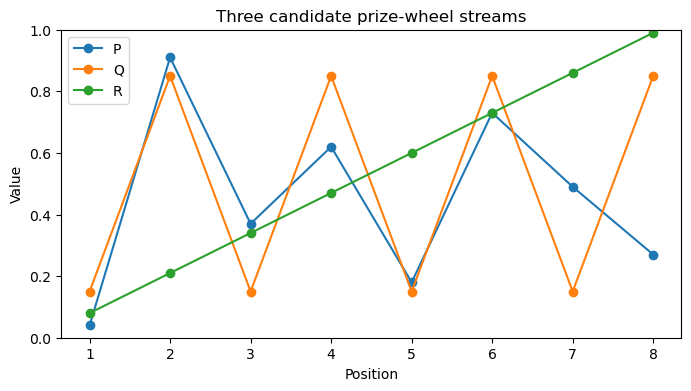

```python
plt.figure(figsize=(8, 4))
plt.plot(streams.index + 1, streams["P"], marker="o", label="P")
plt.plot(streams.index + 1, streams["Q"], marker="o", label="Q")
plt.plot(streams.index + 1, streams["R"], marker="o", label="R")
plt.xlabel("Position")
plt.ylabel("Value")
plt.title("Three candidate prize-wheel streams")
plt.ylim(0, 1)
plt.legend()
plt.show()
```

## Demo Topic 2: Python Random Functions, `default_rng`, and Seeds

Python provides three common interfaces:

| API | Examples | Use |
| --- | --- | --- |
| Standard `random` | `random()`, `randint()`, `choice()`, `shuffle()` | Simple Python programs and lists |
| Legacy `np.random` | `np.random.random()`, `np.random.randint()` | Older NumPy code with shared global state |
| NumPy `Generator` | `rng.random()`, `rng.integers()`, `rng.choice()` | Recommended NumPy interface with explicit state |

### 2.1 Standard-Library `random`

```python
import random
```

```python
random.seed(42)
```

```python
random.random()   # Generate one uniform float in the interval U~[0,1)
```

```
0.2204406220406967
```

```python
random.randint(1, 6)  # Generate one integer from 1 through 6 with both endpoints included
```

```
4
```

```python
random.choice(["tea", "coffee", "juice"])
```

```
'juice'
```

```python
python_items = ["A", "B", "C", "D"]
random.shuffle(python_items)
python_items
```

```
['D', 'A', 'C', 'B']
```

### 2.2 Legacy NumPy Global Functions

Older code often uses the functions below. They share module-level state, so reseeding in one place can affect unrelated code.

```python
np.random.seed(42)   # Set seed
```

```python
np.random.random(5)  # Generate three uniform floats
```

```
array([0.59865848, 0.15601864, 0.15599452, 0.05808361, 0.86617615])
```

```python
np.random.randint(1, 7, size=10)  # Generate "3" integers from 1 through 6
```

```
array([5, 2, 4, 6, 6, 2, 4, 5, 1, 4])
```

```python
np.random.choice(["tea", "coffee", "juice"], size=3)  # Select three items with replacement
```

```
array(['coffee', 'coffee', 'tea'], dtype='<U6')
```

### 2.3 Why We Use `np.random.default_rng()`

NumPy recommends `default_rng()` for new code. It constructs an explicit `Generator`, backed by PCG64 in the installed NumPy version. Separate objects have separate state, can be passed into functions, and do not silently depend on one shared global NumPy generator.

`default_rng` does not mean “proven random.” Period and dependence still matter.

```python
rng = np.random.default_rng(42)    # Construct an explicit Generator from a given seed
```

```python
rng.random(3)                      # Generate three uniform floats in the interval [0,1)
```

```
array([0.77395605, 0.43887844, 0.85859792])
```

```python
rng.integers(1, 7, size=10)  # Generate three integers from 1 through 6 using an exclusive upper bound
```

```
array([1, 4, 6, 5, 5, 5, 5, 4, 1, 6])
```

```python
rng.choice(["tea", "coffee", "juice"], size=3)
```

```
array(['coffee', 'coffee', 'coffee'], dtype='<U6')
```

```python
generator_items = np.array(["A", "B", "C", "D"])
rng.shuffle(generator_items)
generator_items
```

```
array(['B', 'A', 'C', 'D'], dtype='<U1')
```

```python
rng.normal(loc=10, scale=2, size=3)  # Normal with mean 10 and standard deviation 2
```

```
array([12.25448241, 10.93501868,  8.28141507])
```

```python
rng.exponential(scale=3, size=3)  # Exponential with mean 3
```

```
array([0.2747318 , 0.94553761, 2.70359783])
```

### 2.4 Choosing a Generator Method

| Need | Method |
| --- | --- |
| Uniform probability input | `rng.random(n)` |
| Whole-number outcome | `rng.integers(low, high, n)` |
| Category or item | `rng.choice(items, n)` |
| Random ordering | `rng.shuffle(array)` |
| Normal measurement | `rng.normal(mean, sd, n)` |
| Positive waiting time | `rng.exponential(mean, n)` |

Lab 2 focuses on uniform values. Later labs model other inputs.

### 2.5 What Is a Seed?

A seed initializes internal generator state. It is not the first generated number, a sample-size setting, or a quality score.

- Same algorithm plus same seed reproduces the same starting stream.
- Different seeds normally produce different starting streams.
- Nearby seed numbers do not imply nearby outputs.
- A fixed seed supports teaching, debugging, and comparison.
- `default_rng()` without a seed obtains fresh operating-system entropy and is not exactly reproducible.
- Recreating the same seed inside every replication would incorrectly repeat the same stream.

### 2.6 Same Seed, Continued State, and Recreated State

```python
demo_seed = 42
```

```python
rng = np.random.default_rng(demo_seed)
```

```python
first_block = rng.random(5)
first_block
```

```
array([0.77395605, 0.43887844, 0.85859792, 0.69736803, 0.09417735])
```

```python
continued_block = rng.random(5)
continued_block
```

```
array([0.97562235, 0.7611397 , 0.78606431, 0.12811363, 0.45038594])
```

```python
rng = np.random.default_rng(demo_seed)
replayed_block = rng.random(5)
replayed_block
```

```
array([0.77395605, 0.43887844, 0.85859792, 0.69736803, 0.09417735])
```

```python
np.array_equal(first_block, continued_block)
```

```
False
```

```python
np.array_equal(first_block, replayed_block)
```

```
True
```

### 2.7 What Changes When the Seed Changes?

```python
rng_6901 = np.random.default_rng(6901)
values_6901=rng_6901.random(5)
```

```python
rng_6902 = np.random.default_rng(6902)
values_6902=rng_6902.random(5)
```

```python
rng_6903 = np.random.default_rng(6903)
values_6903=rng_6903.random(5)
```

```python
seed_table = pd.DataFrame([values_6901, values_6902, values_6903], index=[6901, 6902, 6903])
seed_table
```

|  | 0 | 1 | 2 | 3 | 4 |
| --- | --- | --- | --- | --- | --- |
| 6901 | 0.016160 | 0.148519 | 0.459067 | 0.246092 | 0.074051 |
| 6902 | 0.755063 | 0.209029 | 0.135558 | 0.447871 | 0.354929 |
| 6903 | 0.745731 | 0.829885 | 0.952702 | 0.564692 | 0.184884 |

**Interpretation:** the seed changes the initialized state and sequence, but all rows still request the same uniform distribution in `[0, 1)`.

## Demo 3: Trace One LCG Update

Use Mini-9: `a=4, c=1, m=9, x0=2`. These parameters are not assessed in the student lab.

```python
current_x = 2  # Set x0
```

```python
raw_value = 4 * current_x + 1
raw_value
```

```
9
```

```python
next_x = raw_value % 9
next_x
```

```
0
```

```python
next_u = next_x / 9  # Getting U
next_u
```

```
0.0
```

## Demo 4: Build a Reusable LCG

```python
def make_lcg(a, c, m, x0, n):  # Define one reusable LCG command
    x_values = []  # List for X
    u_values = []  # List for U
    x = x0  # Seed
    for i in range(n):  # Repeat the LCG calculation n times
        x = (a * x + c) % m
        u = x / m
        x_values.append(x)
        u_values.append(u)
    return pd.DataFrame({"X": x_values, "U": u_values})
```

```python
mini_result = make_lcg(a=4, c=1, m=9, x0=2, n=18)  # Generate two complete Mini-9 cycles
mini_result
```

|  | X | U |
| --- | --- | --- |
| 0 | 0 | 0.000000 |
| 1 | 1 | 0.111111 |
| 2 | 5 | 0.555556 |
| 3 | 3 | 0.333333 |
| 4 | 4 | 0.444444 |
| 5 | 8 | 0.888889 |
| 6 | 6 | 0.666667 |
| 7 | 7 | 0.777778 |
| 8 | 2 | 0.222222 |
| 9 | 0 | 0.000000 |
| 10 | 1 | 0.111111 |
| 11 | 5 | 0.555556 |
| 12 | 3 | 0.333333 |
| 13 | 4 | 0.444444 |
| 14 | 8 | 0.888889 |
| 15 | 6 | 0.666667 |
| 16 | 7 | 0.777778 |
| 17 | 2 | 0.222222 |

```python
((mini_result["U"] >= 0) & (mini_result["U"] < 1)).all()  # Check that every value lies in the correct interval
```

```
True
```

```python
mini_result["X"].nunique()  # Count the distinct integer states in this sample
```

```
9
```

## Demo 5: Find the Period

Exact integer states should be used for period detection. Rounded uniform values can create false matches. A short period repeatedly reuses simulation inputs.

```python
def find_lcg_period(a, c, m, x0):  # Define a function that finds the LCG period
    seen = []
    x = x0
    while x not in seen:  # Continue until an exact state appears again
        seen.append(x)    # Save the state before moving to the next one
        x = (a * x + c) % m
    first_position = seen.index(x)
    return len(seen) - first_position  # Return the repeating cycle length
```

```python
find_lcg_period(a=4, c=1, m=9, x0=2)
```

```
9
```

## Demo 6: Histogram Diagnostic

```python
mini_long_result = make_lcg(a=4, c=1, m=9, x0=2, n=900)  # Generate many Mini-9 values
mini_long_result
```

|  | X | U |
| --- | --- | --- |
| 0 | 0 | 0.000000 |
| 1 | 1 | 0.111111 |
| 2 | 5 | 0.555556 |
| 3 | 3 | 0.333333 |
| 4 | 4 | 0.444444 |
| ... | ... | ... |
| 895 | 4 | 0.444444 |
| 896 | 8 | 0.888889 |
| 897 | 6 | 0.666667 |
| 898 | 7 | 0.777778 |
| 899 | 2 | 0.222222 |

900 rows × 2 columns

```python
mini_values = mini_long_result["U"].to_numpy()
```

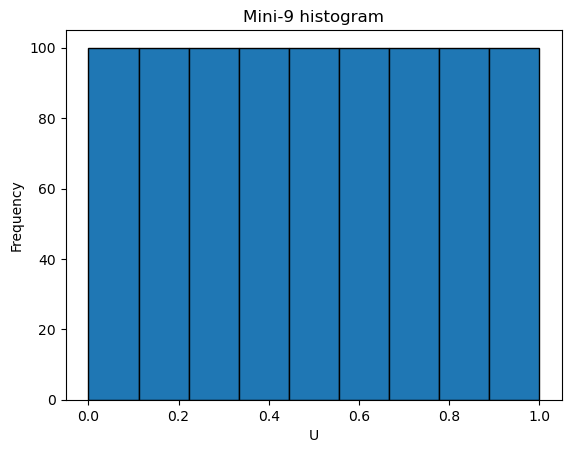

```python
plt.hist(mini_values, bins=9, range=(0, 1), edgecolor="black")  # Draw the Mini-9 histogram
plt.xlabel("U")
plt.ylabel("Frequency")
plt.title("Mini-9 histogram")
plt.show()
```

A repeated short cycle can produce balanced bin counts. A histogram examines marginal coverage, not dependence.

## Demo 7: Successive-Value Diagnostic

```python
mini_pairs = pd.DataFrame({"U_i": mini_values[:-1], "U_next": mini_values[1:]})  # Align every Mini-9 value with its successor
mini_pairs
```

|  | U_i | U_next |
| --- | --- | --- |
| 0 | 0.000000 | 0.111111 |
| 1 | 0.111111 | 0.555556 |
| 2 | 0.555556 | 0.333333 |
| 3 | 0.333333 | 0.444444 |
| 4 | 0.444444 | 0.888889 |
| ... | ... | ... |
| 894 | 0.333333 | 0.444444 |
| 895 | 0.444444 | 0.888889 |
| 896 | 0.888889 | 0.666667 |
| 897 | 0.666667 | 0.777778 |
| 898 | 0.777778 | 0.222222 |

899 rows × 2 columns

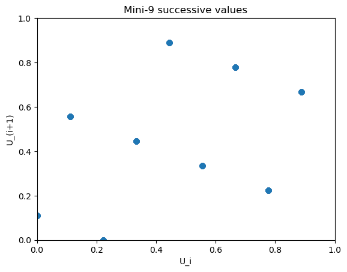

```python
plt.scatter(mini_values[:-1], mini_values[1:])
plt.xlabel("U_i")
plt.ylabel("U_(i+1)")
plt.title("Mini-9 successive values")
plt.xlim(0, 1)
plt.ylim(0, 1)
plt.show()
```

The plot exposes only a small set of deterministic transitions that the balanced histogram hides.

## Demo 8: Compare Mini-9 with NumPy

```python
rng = np.random.default_rng(9)  # Create a NumPy generator with seed 9
numpy_demo_values = rng.random(900)  # Generate the same number of values as the Mini-9 sample
```

```python
comparison = pd.DataFrame({
    "Source": ["NumPy", "Mini-9"],
    "Mean": [numpy_demo_values.mean(), mini_values.mean()],
    "Min": [numpy_demo_values.min(), mini_values.min()],
    "Max": [numpy_demo_values.max(), mini_values.max()],
    "Distinct values": [len(np.unique(numpy_demo_values)), len(np.unique(mini_values))],  # Compare unique-value counts
    "Visible pattern?": ["No obvious pattern", "Yes"],
})
```

```python
comparison
```

[output not shown]

```python
numpy_pairs = pd.DataFrame({"U_i": numpy_demo_values[:-1], "U_next": numpy_demo_values[1:]})
```

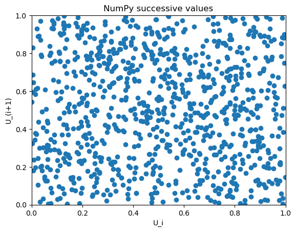

```python
plt.scatter(numpy_demo_values[:-1], numpy_demo_values[1:])
plt.xlabel("U_i")
plt.ylabel("U_(i+1)")
plt.title("NumPy successive values")
plt.xlim(0, 1)
plt.ylim(0, 1)
plt.show()
```

Do not choose a generator from its mean alone. Consider period, distinct values, range coverage, and dependence together.

## Demo 9: Speed and Scale

We compare two ways to generate the **same 50,000 uniform values**:

| Method | What Python does | Number of generator calls written by us |
| --- | --- | --- |
| Method 1: Python loop | Repeats `rng.random()` once per iteration | 50,000 |
| Method 2: NumPy vectorised | Requests the complete array with `rng.random(50000)` | 1 |

For a fair comparison, both methods use:

- seed 42;
- the same NumPy generator type;
- exactly 50,000 values; and
- the same timing function.

We compare elapsed time and confirm that the two methods produced identical values.

```python
timing_size = 50000  # Set the same number of values for both methods
```

### Method 1: Generate One Value at a Time

This method crosses from Python into NumPy 50,000 times. The final expression displays the elapsed seconds automatically.

```python
loop_rng = np.random.default_rng(42)
loop_start = time.time()
loop_values = []  # List for the generated values
for i in range(timing_size):
    loop_values.append(loop_rng.random())  # Generate and store one scalar value
loop_time = time.time() - loop_start
loop_time
```

[output not shown]

### Method 2: Generate the Complete Array

This method makes one vectorised request. The final expression displays the elapsed seconds automatically.

```python
vector_rng = np.random.default_rng(42)  # Recreate the same starting state for the vectorised method
vector_start = time.time()
vector_values = vector_rng.random(timing_size)  # Generate all values in one NumPy call
vector_time = time.time() - vector_start
vector_time
```

[output not shown]

### Compare the Results

The table compares the number of values and elapsed time. The speed ratio shows how many times the loop time exceeds the vectorised time on this computer.

```python
timing_comparison = pd.DataFrame({
    "Method": ["Python loop", "NumPy vectorised"],
    "Number of values": [len(loop_values), len(vector_values)],
    "Elapsed seconds": [loop_time, vector_time],
})
```

```python
timing_comparison
```

[output not shown]

```python
loop_time / vector_time
```

[output not shown]

```python
np.array_equal(np.array(loop_values), vector_values)
```

[output not shown]

**Why?:** vectorised generation is normally faster because the repetition is handled in optimized NumPy code. Exact seconds and the speed ratio vary by computer, so students should compare the methods rather than memorize one timing result.

## Demo 10: Model a Strong Interpretation

> Mini-9 covers its nine possible values evenly, so its histogram initially looks acceptable. However, its period is only nine and the successive-value plot contains only a few repeated transitions. I would use NumPy for a real simulation because the sample contains many distinct values and no obvious low-dimensional pattern. Vectorised NumPy generation is also faster when many values are required. These checks do not prove perfect randomness, but they identify serious weaknesses in Mini-9.

## Transfer Map

| Student task | Demonstrated method |
| --- | --- |
| Build an LCG | List-loop-DataFrame function |
| Find a period | Store exact states until repetition |
| Diagnose a generator | Histogram plus successive-value plot |
| Compare with NumPy | Summary, distinct values, and scatter evidence |
| Compare speed | Same seed and count, loop versus vector call |
| Interpret | Connect period, dependence, choice, and speed |

## Common Errors

- Resetting `x = x0` inside the LCG loop.
- Forgetting modulo or scaling.
- Detecting repetition with rounded values.
- Plotting arrays of unequal lengths.
- Treating a balanced histogram as proof of independence.
- Writing `[0, 1]` instead of `[0, 1)`.
- Timing methods with different seeds or sample sizes.